# Lab 6: Airport Data Science

R-Kelly

2019-02-19

# Main Questions:

# What are the most likely factors to delay flights arriving in Denver?

# What variables, if any, have no predictable effect on arrival delays?

# Findings:

# Peter:

### Personal Section

#### Peter

This plot shows the relative distribution of flights delay times, and their average air speed. This graph shows that there is almost no correlation between arrival delay and airspeed of the flight.

[figure not shown]

```r
Cflights <- mutate(COflights, distAir = DISTANCE/AIR_TIME)
c <- ggplot(data = Cflights, mapping = aes(x = ARR_DELAY, y = distAir)) +
   geom_hex() +
   geom_smooth()
print(c)
```

#### Gregor

Probability of flight that has delayed taxi out is delayed with arrival is:

```
##          n
## 1 10.08853
```

Probability of flight that has delayed taxi in is delayed with arrival is:

```
##          n
## 1 1.621614
```

Creating vectors to contain names and values

```r
x = c("Probability of flights that had late taxi times on arrival being delayed", "Probability of flights that had late taxi times on departure being delayed")

y = c(num_late_taxi_in_delayed[1][1] / count(COflights) * 100, num_late_taxi_out_delayed[1][1] / count(COflights)*100)
```

Creating Tibble

```r
GraphData <- tibble(x, y)
```

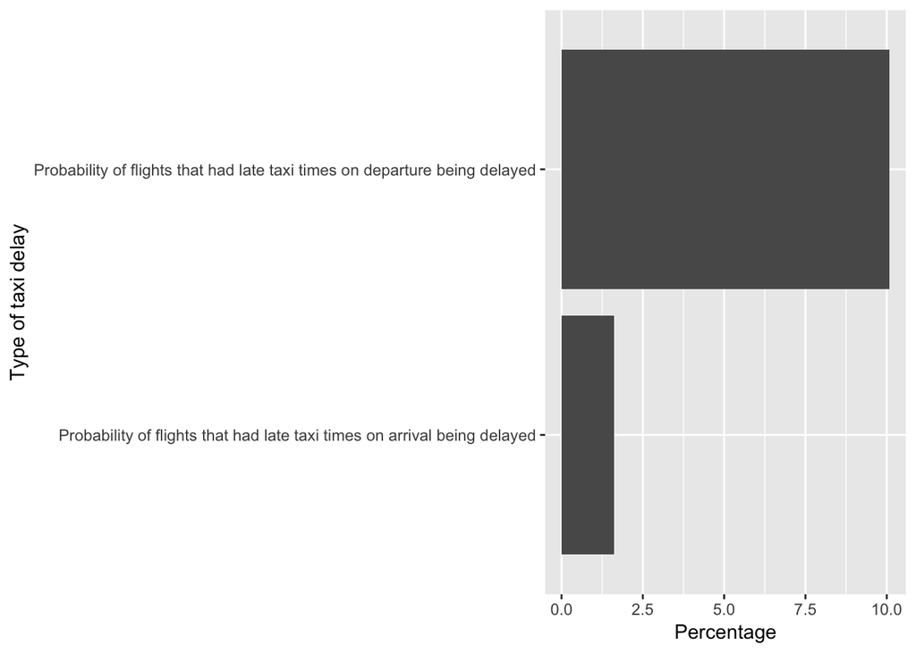

```r
ggplot(data = GraphData, aes(x = x, y = y)) + geom_bar(stat = "identity") + coord_flip() + ylab("Percentage") + xlab("Type of taxi delay")
```

With these results, it is clear that taxing on DENs side doesn’t affect whether the flight is delayed. However, it is unknown whether the arrival time is recorded before or after taxing. If it is recorded after taxing, then this information is significant as it shows that DEN airport is efficient in taxing, since there’s a low chance that flights that are delayed is due to late taxing. However, if the arrival time is recorded before taxing, then this information is insignificant in relation to identifying what DEN airport can do to adjust for preventing delayed flights.

When flights that have a delayed taxi time leaving the origin airport to DEN, there’s about a 10% chance that they will be delayed coming into DEN. The airport could perhaps use this information as if they see a flight has a taxi time of more than 15 minutes, than they can expect that 10% of the time it will be a delayed flight, which can be used to inform people that are awaiting passsengers of that flight.

#### Sasha

```r
 firstHalf <- filter(COflights, DAY_OF_MONTH <= 15)
firstHalfDelayed <- count(filter(firstHalf, ARR_DELAY >= 15))
firstHalfDelayed[1][1] / count(COflights) * 100
```

```
##          n
## 1 8.752981
```

```r
secondHalf <- filter(COflights, DAY_OF_MONTH >15)
secondHalfDelayed <- count(filter(secondHalf, ARR_DELAY >= 15))
secondHalfDelayed[1][1] / count(COflights) * 100
```

```
##          n
## 1 8.483061
```

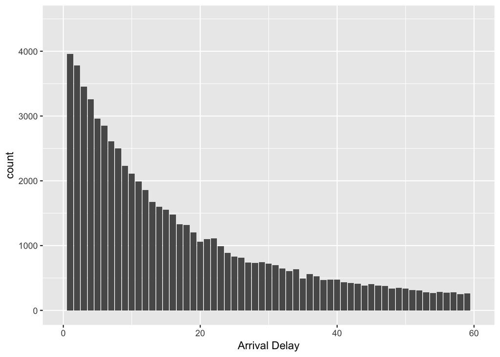

```r
ggplot(data = firstHalf) +
  geom_bar(mapping = aes(x = ARR_DELAY))+ xlim(0,60) + xlab( "Arrival Delay")
```

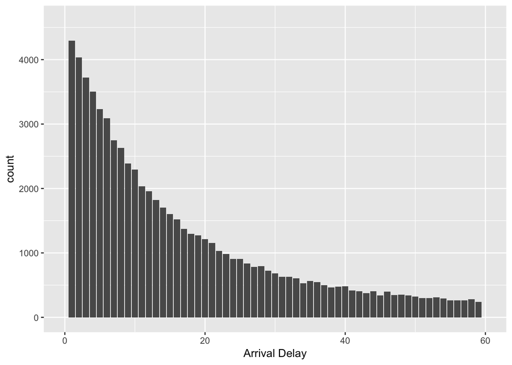

```r
ggplot(data = secondHalf) +
  geom_bar(mapping = aes(x = ARR_DELAY))+ xlim(0,60) + xlab( "Arrival Delay")
```

#### Ping

I try to explore how can the month of the year and the brands of the carriers affect the delay of the flight to Denver.

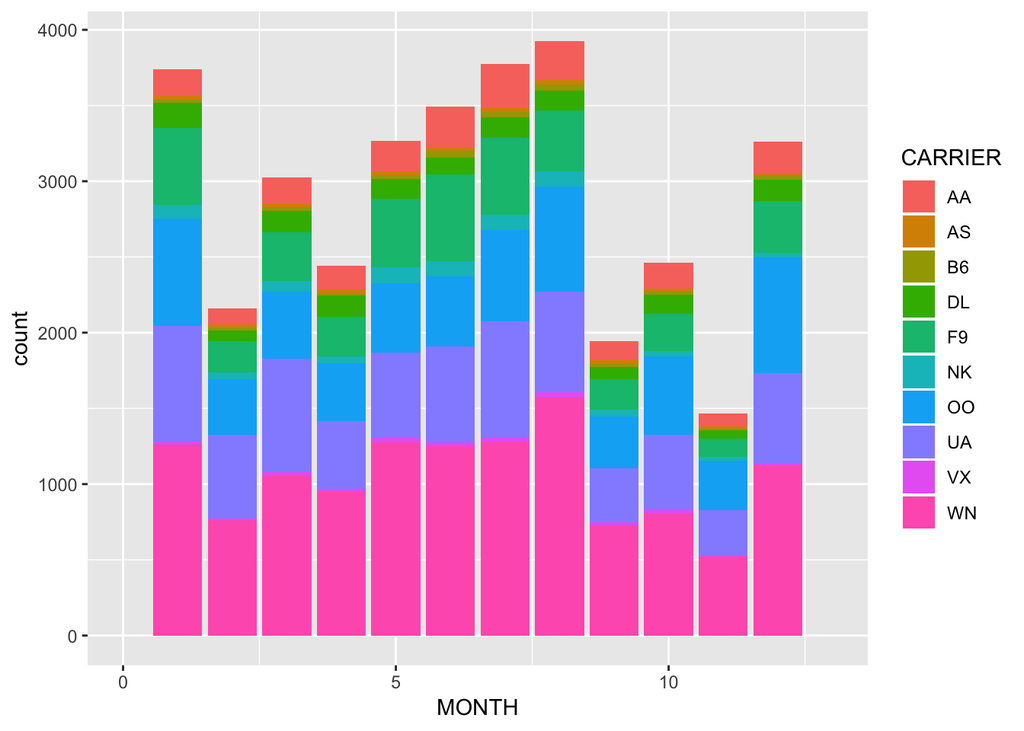

```r
DenDelayed_Month_Carrier <- COflights %>% filter(DEST == "DEN", ARR_DELAY >= 15) %>% select(YEAR, MONTH, CARRIER, ARR_DELAY)
ggplot(data = DenDelayed_Month_Carrier) + geom_bar(mapping = aes(x = MONTH, fill = CARRIER)) + xlim(0,13)
```

## What we did:

### Peter:

I examined the relationship between average airspeed and arrival delay, as well as helped with the formatting of the report and formulation of our research questions.

### Gregor

Examined the probability of flights that have delayed taxi times delaying the actual arrival time of the flight

### Sasha:

I explored the probablity of arrival delay for flights that occur in the first half of the month (until the 15th day) and then also the second half of the month. According to the data, it is more probable that a flight will have an arrival delay earlier in the month as opposed to later.

### Ping:

I explored the relationship between month, carriers and the delayed flights. I also helped with the conclusion of the Team Findings.